# Final Project Analysis

Younjoo Lee

2024-01-31

Load the packages we want.

```r
### Quietly load all packages needed
library(pwr)
library(readxl)
library(dplyr)
library(knitr)
```

1. Load and explore the data

```r
### Load data and descriptive statistics
gpt = read.csv('chat_gpt_experiment_data.csv', header = TRUE)
summary(gpt)
```

```
##        id            duration          guess1            condition
##  Min.   :   1.0   Min.   :  35.0   Min.   :      6.0   Min.   :0.0000
##  1st Qu.: 476.5   1st Qu.: 144.5   1st Qu.:    811.8   1st Qu.:0.0000
##  Median : 952.0   Median : 196.0   Median :   1500.0   Median :1.0000
##  Mean   : 952.0   Mean   : 236.4   Mean   :   7976.7   Mean   :0.9942
##  3rd Qu.:1427.5   3rd Qu.: 277.0   3rd Qu.:   3000.0   3rd Qu.:2.0000
##  Max.   :1903.0   Max.   :1523.0   Max.   :2545000.0   Max.   :2.0000
##                                    NA's   :1
##      guess2            similar        confidence       use_gpt
##  Min.   :     1.5   Min.   :1.000   Min.   :1.000   Min.   :1.000
##  1st Qu.:   900.0   1st Qu.:2.000   1st Qu.:2.000   1st Qu.:1.000
##  Median :  1595.0   Median :3.000   Median :2.000   Median :2.000
##  Mean   :  5252.9   Mean   :2.671   Mean   :2.453   Mean   :2.418
##  3rd Qu.:  3000.0   3rd Qu.:3.000   3rd Qu.:3.000   3rd Qu.:3.000
##  Max.   :900000.0   Max.   :4.000   Max.   :5.000   Max.   :5.000
##  NA's   :407        NA's   :642
```

There were 1903 participants in the study. It took on average 236 seconds or about 4 minutes to complete the study. The average initial guess for the headcount was 7977 heads. But the intial guesses ranged from 6 to 2,545,000 and the median was 1500. The guesses decreased in terms of range and averages for guess 2 but the median increased. The strategies used from the participants were on average somewhat similar or somewhat different to what they received in treatment (if they received a condition). The average confidence was slightly confident. The average use of GPT was ocassionally/sometimes.

2. Test for balance

Are the condition and control groups balanced in terms of prior Chat GPT usage? Do the initial guesses look balanced?

```r
### Calculations for balance
# gpt pre survey question
balance_table0 <- gpt %>%
  group_by(condition) %>%
  summarise(
    mean_use_gpt = mean(use_gpt, na.rm = TRUE),
    N = n()
  )
print(balance_table0)
```

```
## # A tibble: 3 × 3
##   condition mean_use_gpt     N
##       <int>        <dbl> <int>
## 1         0         2.34   641
## 2         1         2.48   632
## 3         2         2.43   630
```

```r
# guess1
balance_table <- gpt %>%
  group_by(condition) %>%
  summarise(
    mean_guess1 = mean(guess1, na.rm = TRUE),
    N = n()
  )
print(balance_table)
```

```
## # A tibble: 3 × 3
##   condition mean_guess1     N
##       <int>       <dbl> <int>
## 1         0       7307.   641
## 2         1       7651.   632
## 3         2       8984.   630
```

It looks like the number of participants in each condition are balanced along with the average use of chatgpt (pre-survey question); however, it looks like condition 2 (expert) has a higher average initial guess compared to condition 0 and 1 by over 1000 heads.

Out of curiosity, what are the mean guesses after exposure to condition?

```r
balance_table2 <- gpt %>%
  group_by(condition) %>%
  summarise(
    mean_guess2 = mean(guess2, na.rm = TRUE),
    N = n()
  )
print(balance_table2)
```

```
## # A tibble: 3 × 3
##   condition mean_guess2     N
##       <int>       <dbl> <int>
## 1         0       5997.   641
## 2         1       3953.   632
## 3         2       5670.   630
```

3. ATE and CI on confidence

```r
  arm_info = gpt %>% group_by(condition) %>% summarise(
    mean_confidence = mean(confidence),
    sd_confidence = sd(confidence),
    N = n(),
    lb = mean_confidence - 1.96*sd_confidence/sqrt(N),
    ub = mean_confidence + 1.96*sd_confidence/sqrt(N),
  )

  ate_info = arm_info %>% mutate(
    ate = mean_confidence - mean_confidence[1],
    se_ate = sqrt( sd_confidence^2 / N + sd_confidence[1]^2/N[1] ),
    lb = ate - 1.96*se_ate,
    ub = ate + 1.96*se_ate
  )

  kable(ate_info, digits = 2)
```

| condition | mean_confidence | sd_confidence | N | lb | ub | ate | se_ate |
| --- | --- | --- | --- | --- | --- | --- | --- |
| 0 | 2.47 | 0.98 | 641 | -0.11 | 0.11 | 0.00 | 0.05 |
| 1 | 2.44 | 0.96 | 632 | -0.14 | 0.07 | -0.04 | 0.05 |
| 2 | 2.45 | 0.93 | 630 | -0.13 | 0.08 | -0.03 | 0.05 |

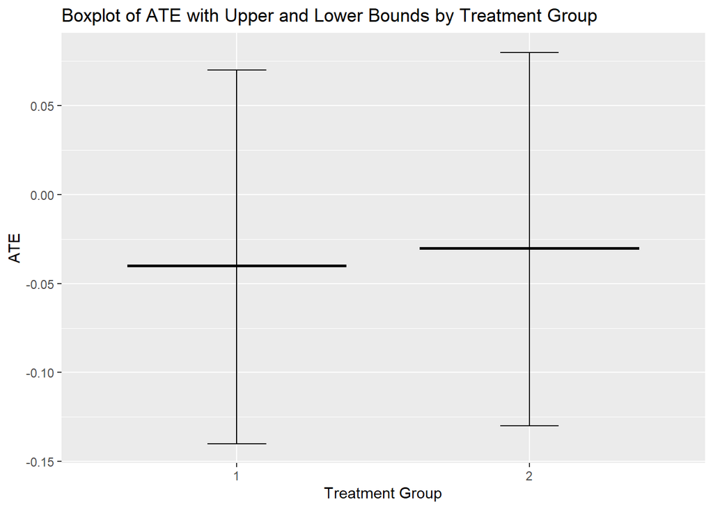

```r
library(ggplot2)
# Create a data frame for the ATE, lb, ub, and condition
ate_data <- data.frame(
  condition = factor(c(1, 2)),
  ate = c(-0.04, -0.03),
  lb = c(-0.14, -0.13),
  ub = c(0.07, 0.08)
)

# Create a boxplot using ggplot2
ggplot(ate_data, aes(x = condition, y = ate)) +
  geom_boxplot(fill = "lightblue", color = "black") +
  geom_errorbar(aes(ymin = lb, ymax = ub), width = 0.2, position = position_dodge(0.9)) +
  labs(x = "Treatment Group", y = "ATE", title = "Boxplot of ATE with Upper and Lower Bounds by Treatment Group")
```

It appears that the ATE for condition 1 and 2 are slightly negative, meaning the confidence of the participants’ answers very slightly drop. However, the upper and lower bounds of the 95% CI for ATE indicate that this is a noisy estimate because they range from negative to positive values, including 0 which rules out a statistically significant effect size. Therefore, there is not a statistically meaningful difference in participants’ confidence in their answers post condition. I would also argue that the ATE of -0.04 for condition 1 and -0.03 for condition 2 are not meaningful in a business or academic setting because the ATE is near zero.

4. Analysis of guesses 1 and 2 - I used ChatGPT to analyze the effect post exposure to the treatments for the differences in their initial and second guess for headcount estimates.

```r
# Used chat GPT for this, I asked:
# How would I analyze the effect after the condition or treatment from guess 1 and guess 2 to calculate the differences and if they're statistically significant
# Paired t-test for condition 0
t_test_result_0 <- t.test(gpt$guess1[gpt$condition == 0], gpt$guess2[gpt$condition == 0], paired = TRUE)

# Paired t-test for condition 1
t_test_result_1 <- t.test(gpt$guess1[gpt$condition == 1], gpt$guess2[gpt$condition == 1], paired = TRUE)

# Paired t-test for condition 2
t_test_result_2 <- t.test(gpt$guess1[gpt$condition == 2], gpt$guess2[gpt$condition == 2], paired = TRUE)

# Check the p-values to determine if the differences are statistically significant
print(t_test_result_0$p.value)
```

```
## [1] 0.4076646
```

```r
print(t_test_result_1$p.value)
```

```
## [1] 0.1356883
```

```r
print(t_test_result_2$p.value)
```

```
## [1] 0.3697864
```

```r
# Calculate the mean differences and confidence intervals
mean_diff_ci_0 <- t.test(gpt$guess2[gpt$condition == 0] - gpt$guess1[gpt$condition == 0])$conf.int
mean_diff_ci_1 <- t.test(gpt$guess2[gpt$condition == 1] - gpt$guess1[gpt$condition == 1])$conf.int
mean_diff_ci_2 <- t.test(gpt$guess2[gpt$condition == 2] - gpt$guess1[gpt$condition == 2])$conf.int

# Check if the confidence intervals exclude zero
print(mean_diff_ci_0)
```

```
## [1] -5126.586  2084.551
## attr(,"conf.level")
## [1] 0.95
```

```r
print(mean_diff_ci_1)
```

```
## [1] -8205.868  1115.810
## attr(,"conf.level")
## [1] 0.95
```

```r
print(mean_diff_ci_2)
```

```
## [1] -704.0134 1888.4217
## attr(,"conf.level")
## [1] 0.95
```

The differences between guess 1 and guess 2 for all conditions 0,1,2 are not statistically significant. The p-value is greater than 0.05, meaning there is not enough evidence to suggest that there is a difference at the 0.05 significance level. Also, the mean difference using the 95% CI for the guesses include 0 which is a noisy estimate, meaning there is not a statistically significant difference.